# Estatística Espacial, Por que estudá-la?

Marcelo José Martins Júnior

# 1. Primeira vez utilizando Estatística Espacial.

Estatística Espacial vem aparecendo frequentemente em programas jornalísticos, quando o assunto é qual região teve maior índice de tal doença, ou até mesmo quando se trata da região mais perigosa, mas ela não se restringe apenas a jornal, esse ramo da Estatística está ajudando várias ciências com seus tipos de dados. E você conhece quais são esses dados e quando eles podem ser utilizados? Ou até mesmo sabe o que é a Estatística Espacial? Esse Post tem como objetivo esclarecer essas dúvidas e te deixar mais interessado por essa parte da grande ciência Estatística.

# 2.Mas o que é Estatística Espacial?

[figure not shown]

Trazendo de forma breve e clara o que seria a Estatística Espacial. ela se delimita sendo um conjunto de métodos de análise de dados em que a localização geográfica é usada explicitamente na modelagem.

# 3. Mas ela deve ser utilizada em todos os casos?

Muitos estudos não fazem uso da informação espacial. No entanto, em alguns casos, essas referências espaciais são importantes na análise.

## Exemplos:

- Epidemologia
- Estudos de violência
- Agronomia
- Demografia
- Geologia

# 4.Tipos de dados espaciais:

Para esse tópico vamos ver alguns tipos de dados Espaciais, e assim sendo entender a grande importância de seu estudo para as ciências em geral.

## 4.1 Dados de área

- São dados usualmente obtidos através de levantamentos populacionais, tais quais censos, estatísticas de saúde,cadastramentos populacionais, entre outros, agregados por áreas de uma região. As áreas são subdivisões do mapa (tradicionalmente chamamos todo o espectro geográfico por região),as áreas constituem partições de caráter administrativo, político ou geofísico.

[figure not shown]

## 4.2 Processos Pontuais

- São aqueles que identificam eventos ou fenômenos como pontos localizados no espaço. Neste caso, o interesse principal consiste nas coordenadas geográficas que representam a localização exata dos acontecimentos. Na prática, dados relacionados à crimes são um exemplo dos frequentemente estudados. O foco é a detecção de padrões e fontes de influência (se aleatórios ou não) para distribuição espacial dos pontos.

[figure not shown]

## 4.3 Superfícies Contínuas, Geoestatística ou Superfícies Aleatórias

Os dados se tratam de amostras de campo, regular ou irregularmente distríbuidos. Em situações cotidianas, normalmente as amostras são derivadas de estações fixas de monitoração, coleta ou mediação de certa variável de interesse. O objetivo da análise deste tipo de dado é de modelar uma superfície espacial que represente o comportamento da variável em estudo no espaço geográfico.

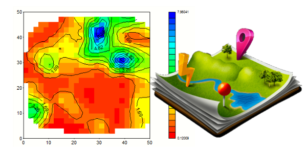

## 4.4 Dados de Interação Espacial

Estes dados, cuja localização é considerada fixa tal qual em Geoestatística, correspondem a um par ordenado que indicam ponto de saída (origem) e ponto de chegada (destino). Através destes, se torna viável compreender o comportamento dos fluxos, mediante da modelagem, que pode inclusive permitir predizer efeitos oriundos de alterações no cenário dos mesmos.

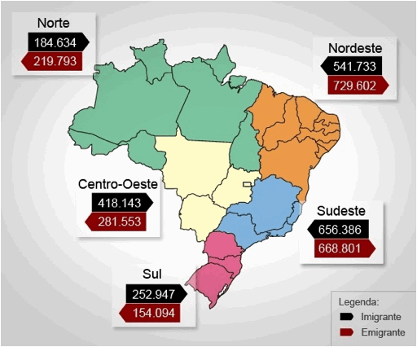

# 5. Conclusão

Assim concluímos que a estatística espacial deve ser estudada a fundo devido ser tão importante não só para a estatística, mas para boa parte das outras ciências que coletam dados e usam a geografia como modelo.

# Fontes

[Estatística Espacial em Dados de Área: Uma Modelagem Inteiramente Bayesiana para o Mapeamento de Doenças Aplicadas à Dados Relacionados com a Natalidade em Mulheres Jovens de Porto Alegre](https://www.lume.ufrgs.br/bitstream/handle/10183/36929/000572769.pdf?sequence=1)

[Introdução a Estatística Espacial](http://www.observatoriodasmetropoles.ufrj.br/download/aulasanalise-espacial.pdf)

[Análise Espacial de áreas](http://www.dpi.inpe.br/gilberto/livro/analise/cap5-areas.pdf)

[Análise Espacial de superfícies](http://www.dpi.inpe.br/gilberto/tutoriais/analise/cap3.pdf)

[figure not shown]